# Expectation-Maximization

João Neto

October 2014

Refs:

- Data Mining Algorithms In R/Clustering/Expectation Maximization (EM)
- Bishop, **Pattern Matching and ML**, chapter 9.

The EM algorithm is a methodology for algorithm construction, it is not a specific algorithm. Each problem is different, only the structure of the Expectation and Maximization steps are common. How exactly they are programmed is problem dependent.

# The (Meta-)Algorithm

We observed data $X$ and have a (possibly made up) set of latent variables $Z$. The set of model parameters is $\theta$.

The goal of the EM algorithm is to find a maximum to the likelihood function $p(X|\theta)$ wrt parameter $\theta$, when this expression or its log cannot be discovered by typical MLE methods.

Suppose for each observation $x^i\in X$ we get the corresponding value $z^i \in Z$. $\{X,Z\}$ is called the complete dataset. The likelihood for the complete set is $p(X,Z|\theta)$. However we do not know the complete set, only $X$. To proceed we need to construct the posterior $p(Z|X,\theta)$. Usually this is the part that requires some imagination/luck/experience.

With $p(Z|X,\theta)$ we can compute the likelihood for the complete set:

$p(X,Z|\theta) = p(Z|X,\theta) p(X|\theta)$

Assume also that we know an estimate $\theta_i$ for $\theta$. This allows us to compute the posterior $p(Z|X,\theta_i)$. Initially $\theta_i=\theta_0$ is randomly assigned.

The log-likelihood is

$\log p(X|\theta) = \log \{ \sum_z p(X,Z=z|\theta) \} = \log \{ \sum_z p(X|Z=z,\theta) p(Z=z|\theta) \}$

as given by the marginal rule of probability. For continuous latent variables, the sum is replaced by an integral. The EM algorithm will maximize $\log p(X|\theta)$, but since $\log$ is a strict monotonous function, it will also maximize $p(X|\theta)$.

With these equations let’s see what EM should do.

Given a current estimate $\theta_i$ we wish to find an update $\theta$ such that $p(X|\theta) > p(X|\theta_i)$ (remember, if that cannot be done, the algorithm found a maximum and we are over). If possible we want to maximize the difference between $p(X|\theta)$ and $p(X|\theta_i)$:

$\begin{array}{lclr} & & \log p(X|\theta) - \log p(X|\theta_i) & \\ & = & \log \left\{ \sum_z p(X|Z=z,\theta) p(Z=z|\theta) \right\} - \log p(X|\theta_i) & \color{blue}{\text{marginal rule}} \\ & = & \log \left\{ \sum_z p(X|Z=z,\theta) p(Z=z|\theta) \frac{p(Z=z|X,\theta_i)}{p(Z=z|X,\theta_i)} \right\} - \log p(X|\theta_i) & \\ & = & \log \left\{ \sum_z p(Z=z|X,\theta_i) \frac{p(X|Z=z,\theta) p(Z=z|\theta)}{p(Z=z|X,\theta_i)} \right\} - \log p(X|\theta_i) & \\ & \geq & \sum_z p(Z=z|X,\theta_i) \log \left\{ \frac{p(X|Z=z,\theta) p(Z=z|\theta)}{p(Z=z|X,\theta_i)} \right\} - \log \color{red}{p(X|\theta_i)} & \color{blue}{\log \sum_i a_ix_i \geq \sum_i a_i\log x_i, \text{Jensen Ineq.}}\\ & = & \sum_z p(Z=z|X,\theta_i) \log \left\{ \frac{p(X|Z=z,\theta) p(Z=z|\theta)}{p(Z=z|X,\theta_i)\color{red}{p(X|\theta_i)}} \right\} & \color{blue}{\text{multiply} \sum_z p(Z=z|X,\theta_i)=1 \text{ by } p(X|\theta_i)} \\ & \equiv & \Delta(\theta|X,\theta_i) & \color{blue}{\equiv\text{: by definition}}\\ \end{array}$

So, $\log p(X|\theta) \geq \log p(X|\theta_i) + \Delta(\theta|X,\theta_i) \equiv Q(\theta|\theta_i)$

This new function $Q(\theta|\theta_i)$ is bounded above by the likelihood $\log p(X|\theta)$. They are equal at $\theta=\theta_i$.

The goal of the EM algoritm is to choose $\theta_{i+1}$ as the value of $\theta$ such that $Q(\theta|\theta_i)$ is a maximum. Since $\log p(X|\theta_{i+1}) \geq Q(\theta_{i+1}|\theta_i)$ we ensure that the likelihood also rises as much as possible.

$\begin{array}{lclr} \theta_{i+1} & = & \arg \max_{\theta} Q(\theta|\theta_i) & \\ & = & \arg \max_{\theta} \left\{ \log p(X|\theta_i) + \sum_z p(Z=z|X,\theta_i) \log \frac{p(X|Z=z,\theta) p(Z=z|\theta)}{p(Z=z|X,\theta_i)p(X|\theta_i)} \right\} & \\ & = & \arg \max_{\theta} \left\{ \sum_z p(Z=z|X,\theta_i) \log p(X|Z=z,\theta) p(Z=z|\theta) \right\} & \color{blue}{\text{remove constants wrt } \theta} \\ & = & \arg \max_{\theta} \left\{ \sum_z p(Z=z|X,\theta_i) \log \frac{p(X,Z=z,\theta) p(Z=z,\theta)}{p(Z=z,\theta)p(\theta)} \right\} & \color{blue}{p(X|Y) = \frac{p(X,Y)}{p(Y)}} \\ & = & \arg \max_{\theta} \left\{ \sum_z p(Z=z|X,\theta_i) \log p(X,Z=z|\theta) \right\} & \\ & = & \arg \max_{\theta} \left\{ E_{Z|X,\theta_i} [ \log p(X,Z|\theta) ] \right\} & \color{blue}{E_Z [ g(Z) ] = \sum_z f(Z)g(Z)} \\ \end{array}$

So, the EM algorithm is:

0. Have $X$ and $p(Z|X,\theta)$.
1. $\theta_i \leftarrow \theta_0$, where $\theta_0$ is a random assignment of values.
2. **E-step**: Compute $Q(\theta|X,\theta_i) = E_{Z|X,\theta_i} [ \log p(X,Z|\theta) ]$
3. **M-step**: Compute $\theta_{i+1} \leftarrow \arg\!\max_{\theta} Q(\theta|X,\theta_i)$
4. If $\theta_i$ and $\theta_{i+1}$ are not close enough, $\theta_i \leftarrow \theta_{i+1}$ and goto 2.

There is a [convergence proof](http://seanborman.com/publications/EM_algorithm.ps.gz) that states $\Delta(\theta_{i+1}|X,\theta_i) \geq 0$, which means the EM algorithm stops eventually. However, there is no garantee that a global maximum is achieved. That’s why it is sometimes needed to run the algorithm with different values for $\theta_0$. The assigment of $\theta_0$ is th eonly random element in the entire EM algorithm, which is why it is called an deterministic optimization technique.

An eg using EM with mixture of Gaussians can be found [here](http://www.di.fc.ul.pt/~jpn/r/EM/GaussianMix.html).

# EM for clustering

The EM algorithm can be seen an unsupervised clustering method based on [mixture models](http://en.wikipedia.org/wiki/Mixture_model). It follows an iterative approach, sub-optimal, which tries to find the parameters of the probability distribution that has the [maximum likelihood](http://en.wikipedia.org/wiki/Maximum_likelihood) of its attributes in the presence of missing/latent data.

The algorithm’s input are the data set $X$, the total number of clusters/models $K$, the accepted error to converge $\epsilon$ and the maximum number of iterations.

For each iteration, first it is executed what’s called the Expectation Step (E-step), that estimates the probability of each point belonging to each model, followed by the Maximization step (M-step), that re-estimates the parameter vector of the probability distribution of each model. The algorithm finishes when the distribution parameters converges or reach the maximum number of iterations. Convergence is assured since the algorithm increases the likelihood at each iteration until it reaches the (eventually local) maximum.

## Eg: EM with mix of two linear models

- Ref: http://www.cs.huji.ac.il/~yweiss/emTutorial.pdf

Let’s have a dataset generated by either one of two linear processes $C_1$ and $C_2$:

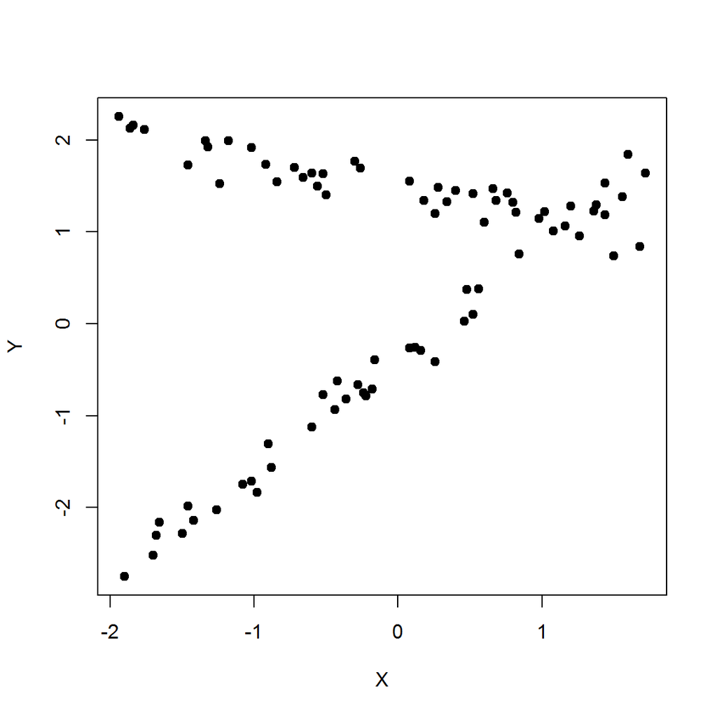

```r
set.seed(101)

slope1 <- -.3; intercept1 <- 1.5    # generating data from C_1
xs1 <- sample(seq(-2,2,len=201), 40)
ys1 <- intercept1 + slope1*xs1 + rnorm(length(xs1),0,.15) # add some noise

slope2 <- 1.2; intercept2 <- -.4    # generating data from C_2
xs2 <- sample(seq(-2,2,len=201), 40)
ys2 <- intercept2 + slope2*xs2 + rnorm(length(xs1),0,.15)

mydata <- rbind( cbind(xs1,ys1), cbind(xs2,ys2) )
plot(mydata, pch=19, xlab="X", ylab="Y")
```

We need to achieve two things:

- The parameters, slope and intersect, of the two models
- The assigment of each datapoint $x^i$ to the modelled process that generated it

If we know one the other should be easy to find. If we know the parameters, we could apply a maximum likelihood estimation to find which model is more probable to have generated $x^i$, i.e., compute $p(x^i | C_j)$. If we know the classifications we could just perform two linear regressions in order to find the parameters.

This is the basic structure of the EM algorithm:

1. Init-step: Assign random values to the model’s parameters
2. E-step: assign points to the model that fits each one best (these assignments are continuous, not binary)
3. M-step: update the parameters using the points assigned in the previous step
4. Iterate until parameter values converge

**Init Step**

```r
i1 <- s1 <- i2 <- s2 <- 0 # model parameters for slope and intersect
init_params <- function() {
  i1 <<- 2*runif(1)
  s1 <<- 2*runif(1)
  i2 <<- 2*runif(1)
  s2 <<- 2*runif(1)
  c(i1,s1,i2,s2)
}

params <- init_params()
```

**E-step:**

For each point $x^i$ compute two weights (probabilities) $w_1^i$ and $w_2^i$ for the soft assigments of model 1 and 2.

We calculate the residuals $r^i$ of the two models for each $x^i$:

$r_j^i = | \text{intersect}_j + \text{slope}_j x^i - y^i |$

So,

$w_j^i = \frac{p(r_j^i | x^i \in C_j)}{p(r_1^i | x^i \in C_1) + p(r_2^i | x^i \in C_2)}$

If we assign normal distributions to these probabilities

$r_j^i | x^i\in C_j \sim \mathcal{N}(0,\sigma^2)$

which means

$p(r_j^i | x^i \in C_j) = \frac{1}{\sqrt{2\pi}\sigma} \exp\{-\frac{(r_j^i)^2}{2\sigma^2}\}$

plugging the distributions into the $w_j^i$ formula:

$w_j^i = \frac{\exp\{-\frac{(r_j^i)^2}{2\sigma^2}\}} {\exp\{-\frac{(r_1^i)^2}{2\sigma^2}\} + \exp\{-\frac{(r_2^i)^2}{2\sigma^2}\}}$

The $\sigma$ is a free parameter. This corresponds to the expected noise level in the sample. Herein we’ll assume $\sigma=0.5$. Values too small might produce underflows in R, especially in the first iterations of the EM algorithm.

```r
# params is [s1,i1,s2,i2]
e.step <- function(mydata, params, sigma=0.5) {
  w1 <- rep(NA, nrow(mydata))
  w2 <- rep(NA, nrow(mydata))

  for (i in 1:nrow(mydata)) {
    r1 <- abs(params[1] + params[2] * mydata[i,1] - mydata[i,2]) # residual for model 1
    r2 <- abs(params[3] + params[4] * mydata[i,1] - mydata[i,2]) # residual for model 2

    exp1 <- exp(-r1^2/sigma^2)
    exp2 <- exp(-r2^2/sigma^2)

    w1[i] <- exp1 / (exp1+exp2)
    w2[i] <- exp2 / (exp1+exp2)
  }

  cbind(w1,w2)
}

ws <- e.step(mydata, params)
head(ws)
```

```
##             w1     w2
## [1,] 1.959e-04 0.9998
## [2,] 1.040e-30 1.0000
## [3,] 2.547e-01 0.7453
## [4,] 5.015e-01 0.4985
## [5,] 4.996e-12 1.0000
## [6,] 7.438e-08 1.0000
```

**M-step:**

Here we assume the weights are given for each data point $x^i$.

To estimate the parameters of each process we use [weighted least squares](https://onlinecourses.science.psu.edu/stat501/node/213).

In classic least squares, the parameters $p_i$ for the $i^{\text{th}}$ model would be given by:

$\hat{p_i} = (X_i^T X_i)^{-1} X_i^T Y$

To add weights $w_i$ we make a diagonal matrix $W_i$ with these values and compute:

$\hat{p_i} = (X_i^T W_i X_i)^{-1} X_i^T W_i Y$

```r
# wls - weighted least squares
wls <- function(X,Y,W) {
  solve(t(X) %*% W %*% X) %*% t(X) %*% W %*% Y
}

m.step <- function(mydata, ws) {
  X <- cbind(rep(1, nrow(mydata)), mydata[,1])
  Y <- as.matrix(mydata[,2], ncol=1)
  p_1 <- wls(X,Y,diag(ws[,1]))
  p_2 <- wls(X,Y,diag(ws[,2]))

  c(p_1, p_2)
}

params <- m.step(mydata, ws)
```

Let’s put everything together for this problem:

```r
em.2lines <- function(mydata, tol=1e-2, max.step=1e3) {
  step <- 0

  s1 <- i1 <- s2 <- i2 <- 0 # model parameters for slope and intersect
  params <- init_params()

  repeat {
    ws         <- e.step(mydata, params)
    old.params <- params
    params     <- m.step(mydata, ws)

    if (norm(as.matrix(old.params-params), type="F") < tol) # convergence achieved
      break

    step <- step +1
    if (step > max.step)
      break
  }

  list(params=params,    # the estimated parameters
       weights=ws,       # the weighs for each datapoint x^i
       class=apply(ws, 1, function(v) if (v[1]>v[2]) 1 else 2))  # the class for each datapoint
}

report <- em.2lines(mydata)
report$params
```

```
## [1] -0.3648  1.2282  1.4906 -0.2982
```

Let’s plot the results:

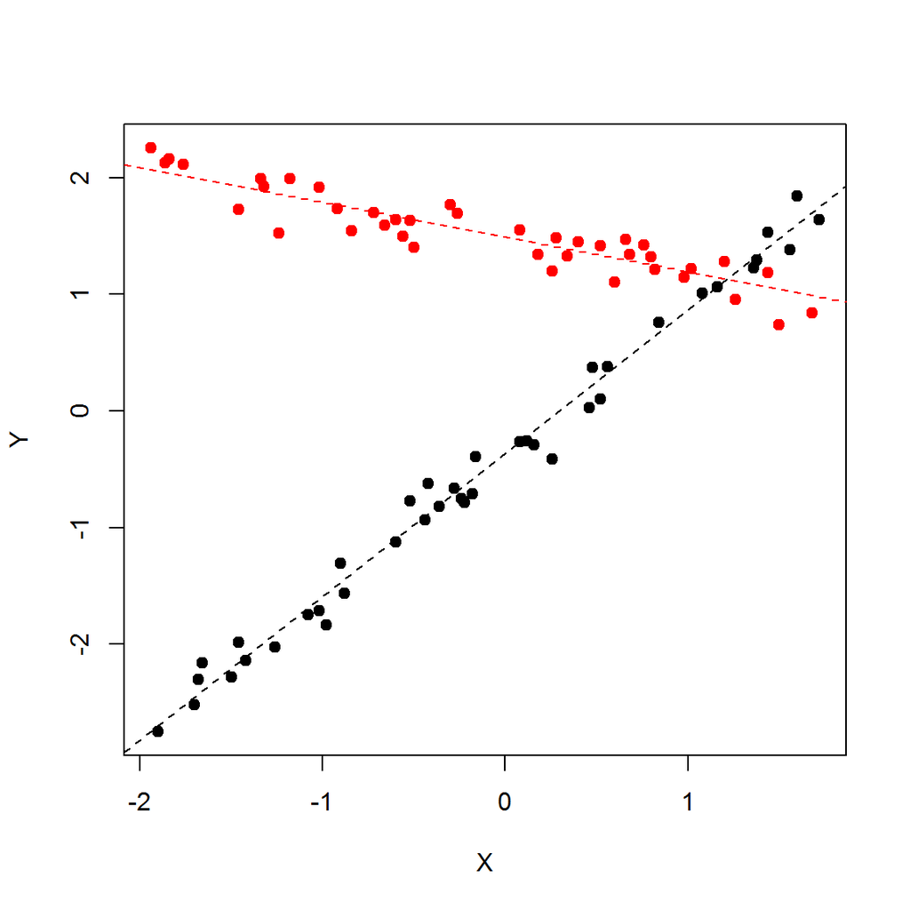

```r
plot(mydata, pch=19, col=report$class, xlab="X", ylab="Y")
abline(a=report$params[1], b=report$params[2], col=1, lty=2) # draw 1st model with found parameters
abline(a=report$params[3], b=report$params[4], col=2, lty=2) # draw 2nd model with found parameters
```

## Using R’s mclust for classification

Using `Mclust` from package `mclust` to find the optimal model for a given dataset and number of clusters based on EM:

```r
library(MASS)
library(mclust)
```

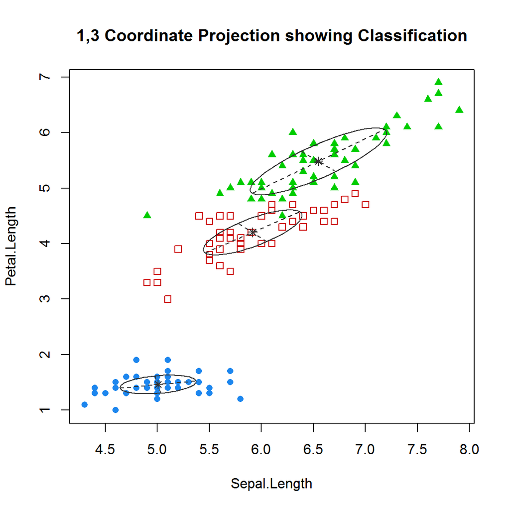

```r
mc <- Mclust(iris[,1:4], G=3) # 3 clusters
plot(mc, what=c("classification"), dimens=c(1,3)) # using 1st and 3rd column of the iris dataset
```

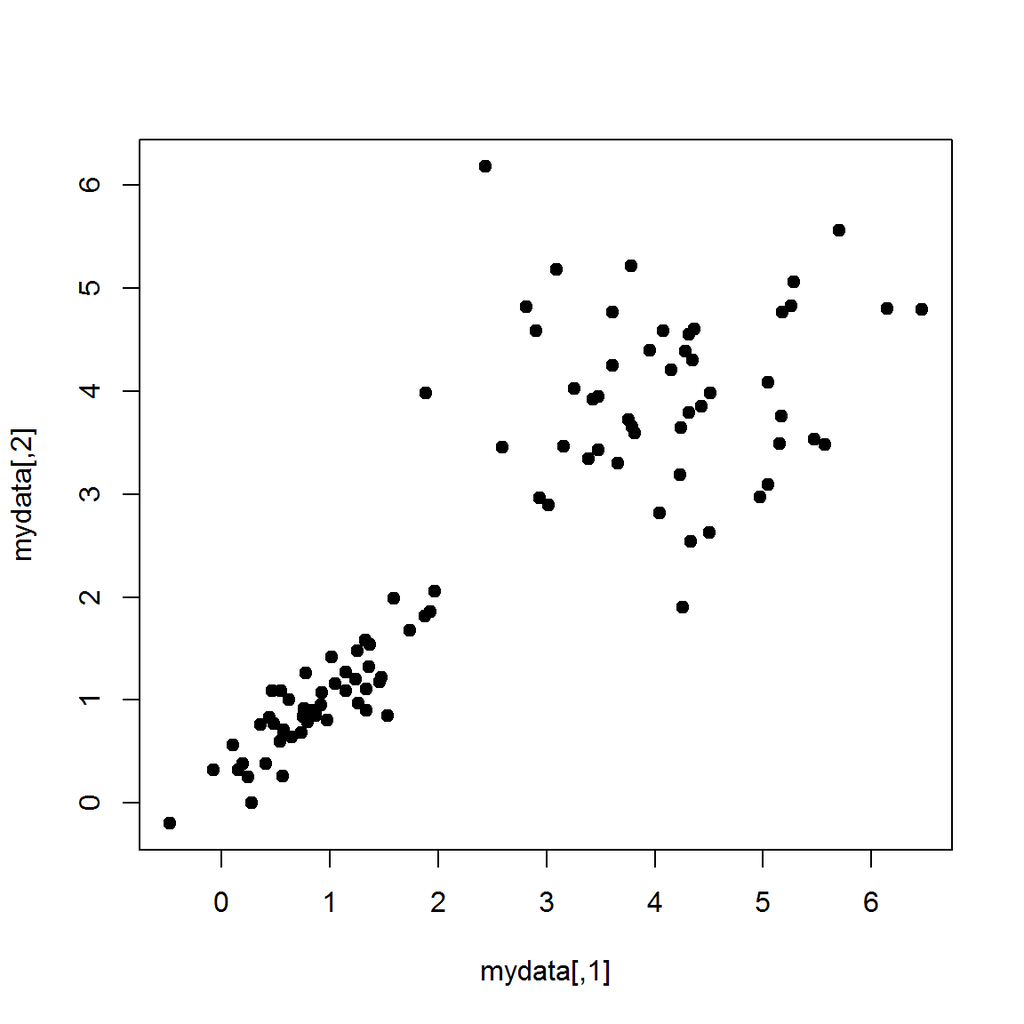

```r
# make dataset with points from two different multivariate normal densities
mydata <- rbind(mvrnorm(50, c(1,1), matrix(c(.5^2,.20,.20,.5^2), ncol=2)),
                mvrnorm(50, c(4,4), matrix(c(1,0,0,1), ncol=2)))
plot(mydata, pch=19)
```

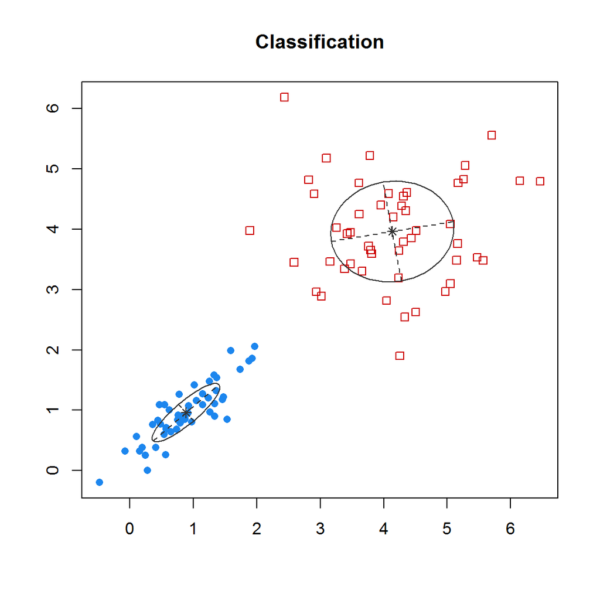

```r
mixclust <- Mclust(mydata)  # if G is not given, it will test between 1 to 9
plot(mixclust, what=c("classification"))  # plot the distinct clusters found
```